# hw3_gz2280

#### Problem 1.

a) First we can generate a squared uniformly distributed area which covers our density of curve $p$. To do so we are required to know the global maximum of $p$ as well as the range of $x$. After this, we could apply rejection method to our region, that is, if $Y_i > p(X_i)$ we reject this couple of $(X_i, Y_i)$. Repeat many times until we have $n$ samples, and they are all independent uniformly distributed under $p$.

b) Since our model is already trained, when increasing the value of $v$ it would not affect the decision boundary but reduce our log-likelihood function value. In a overfitted model, our boundary would be very close to the trainning data, which makes it a bad predictor for new incoming data.

c) $X_n$ and $X_2$ are conditional independent, conditioned on each hidden variables between them: $Z_2, Z_3, \dots, Z_n$. First for hidden variables they follow Markovian rule that each variable are conditional independent. Plus the emission probability is a conditional probability, which gives us that $P(X_n|X_2)$ can be write as a combination of conditional probability functions, therefore they are conditional independent.

#### Problem 2.

Intuition: $f(x_1,x_2)=1$ for $x_1=x_2$, implies that $f$ should be a function which goes through point $0$ and has $\text{slope}=1$.

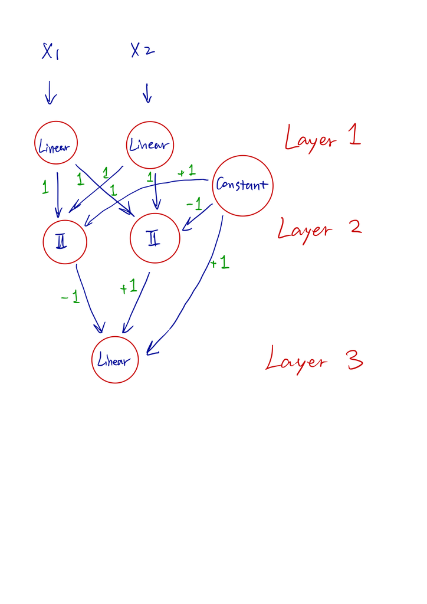

```python
from IPython.display import Image
display(Image('1111.png',width=500, height=700))
```

The first layer is two linear functions $f_1(x)=x$.

The second layer is the indicator function $\text{I}_{2}(x) = 1 \text{ ( if x>0 )}$.

The third layer is a linear function $f_3(x)=x$.

Besides, we have a constant function $C$.

All weights are given as graph shows.

Test for networks:

$$(x_1,x_2)=(1,1)=>\text{Layer 1: }(1,1) => \text{Layer 2: }(1,1)=> \text{Layer 3: }(1)$$$$(x_1,x_2)=(-1,-1)=>\text{Layer 1: }(-1,-1) => \text{Layer 2: }(0,0)=> \text{Layer 3: }(1)$$$$(x_1,x_2)=(1,-1)=>\text{Layer 1: }(1,-1) => \text{Layer 2: }(1,0)=> \text{Layer 3: }(0)$$$$(x_1,x_2)=(-1,1)=>\text{Layer 1: }(-1,1) => \text{Layer 2: }(1,0)=> \text{Layer 3: }(0)$$

Therefore we construct our $f(x)$.

#### Problem 3.

The observed sample consist of one data point in category 3.

#### Problem 4.

For $x$:

$$\phi (\mathbb{wx-c})=\phi(\frac{-7}{2\sqrt{2}}) = 0$$

For $x'$:

$$\phi (\mathbb{wx'-c})=\phi(\frac{1}{2\sqrt{2}}) = 1$$

#### Problem 5.a.

$$q(x)\sim unif([0,1])$$$$q(x)=1$$$$p(x)=2x$$

To keep $p$ under $q$, we need $p(x) \le Mq(x)=q(x)$:

$$M \ge \frac{p(x)}{q(x)}=2x \text{, for x}\in (0,1)$$

Since we need to keep rejected samples as small as possible, our scale factor $M$ should be small enough, but $M$ should be suitable for all $x$, which gives us $M=2$.

#### Problem 5.b.

The acceptance rate for rejection is $\frac{1}{M}=50\%$

Since $m=50\%n$, we have $n=2m$.

#### Problem 6.a.

$$P(X_i \le x|R)=\frac{P(X_i \le x, U_i > \frac{p(X_i)}{kr(X_i)})}{P(U_i > \frac{p(X_i)}{kr(X_i)})}=\frac{\int_{-\infty}^x[\int_{p(x_i)/kr(x_i)}^{1} dy]r(x_i)dx_i}{\int_{-\infty}^{\infty}[\int_{p(x_i)/kr(x_i)}^{1} dy]r(x_i)dx_i}=\frac{\int_{-\infty}^x[kr(x_i)-p(x_i)]dx_i}{\int_{-\infty}^{\infty}[kr(x_i)-p(x_i)]dx_i}=\frac{k\int_{-\infty}^x r(x_i)dx_i-\int_{-\infty}^x p(x_i)dx_i}{k-1}$$

There we can find p.d.f. of $X_i \le x | R$:

$$p(X_i \le x | R) = \frac{kr(x)-p(x)}{k-1}$$

#### Problem 6.b.

Apply importance sampling to $\theta$:

$$\mathbb{E}_{p}[f(X)]=\frac{1}{N}\sum_{i=1}^N h(X_i)\frac{p(X_i)}{kr(X_i)}$$

We split $N$ into two parts: $A$: acception and $R$: rejection:

$$\mathbb{E}_{p}[f(X)]=\frac{1}{N}[\sum_{i=Z_i:A} h(X_i)\frac{p(X_i)}{kr(X_i)}+\sum_{i=Z_i:R} h(X_i)\frac{p(X_i)}{kr(X_i)}]$$

Since we know that when Accept: $kr(x)=p(x|A)$ and when Reject: $kr(x)=p(x|R)$, we substitute them respectively:

$$\mathbb{E}_{p}[f(X)]=\frac{1}{N}[\sum_{i=Z_i:A} h(x)\frac{p(x)}{\color{red}{p(x|A)}}+\sum_{i=Z_i:R} h(x)\frac{p(x)}{\color{red}{p(x|R)}}]$$

Now from previous calculation we have, $(X_i|Z_i=A) \sim p(x)$ and $( X_i|Z_i=R)\sim \frac{kr(x)-p(x)}{k-1}$, we have:

$$\mathbb{E}_{p}[f(X)]=\frac{1}{N}[\sum_{i=Z_i:A} h(x)\frac{p(x)}{\color{red}{p(x)}}+\sum_{i=Z_i:R} h(x)\frac{p(x)}{\color{red}{\frac{kr(x)-p(x)}{k-1}}}]$$

After simplification,

$$\mathbb{E}_{p}[f(X)]=\frac{1}{N}[\sum_{i=Z_i:A} h(x)+\sum_{i=Z_i:R} h(x)\frac{(k-1)p(x)}{kr(x)-p(x)}]$$

Which is $\delta$.